# Introduction to Quarto

Author

Professor MacDonald

Published

January 8, 2025

# Quarto introduction

Quarto is a document container that allows you to mix text and code to produce reproducible (see [here](https://www.displayr.com/what-is-reproducible-research/) for why reproducibility is important) results and auto-generate high quality document.

# Practicing with Quarto

To complete this lab, please do a simple investigation into the distribution of `mpg` (miles per gallon) and `wt` (weight) from the `mtcars` built-in dataset.

1. Select File->New Quarto Document
2. Insert a code block and then make a histogram of `mpg`
3. Add some text that describes the three features of the `mpg` distribution (shape, center, spread)
4. Repeat for the variable `wt`
5. Add appropriate headers for each section and make sure you can navigate between them using the navigation windows
6. Write a brief conclusion of your investigation and then Render the result as an HTML file

A few additional tips to help you along:

## Editing your document

RStudio has two views for editing your document, `Source` and `Visual`.

Most people find it easier to edit using the Visual mode. Switch back and forth between the two views to check the differences.

Note that at the top of your document is a special section that defines important attributes of how your document will render.

These options are contained within a set of — charcters. This section must be at the top of your document. *You cannot put code in this section and it must always be at the top of your document. It is a document header that defines how the document will Render*

- Using the list of options [here](https://quarto.org/docs/reference/formats/html.html), add a subtitle and abstract to rendering options block.

## Insert code block

In particular, you will need to use the Insert a new code chunk button to add a code block

[figure not shown]

The code block, like the one shown below, has some options for the code block. In this case, I added the line `#| echo: true` which means that both the code and the results of the code will be printed on the document. By default, only the results of the code will be shown.

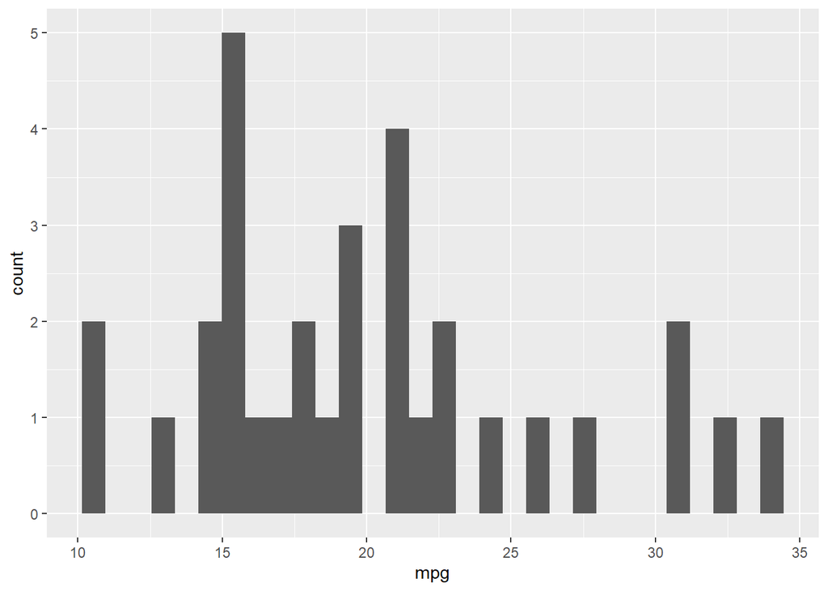

Histogram of variable: MPG

```r
ggplot(mtcars, aes(x=mpg)) +
  geom_histogram()
```

```r
mtcars %>%
  summarise(mean_mpg = mean(mpg),
            sd_mpg= sd(mpg))
```

```
  mean_mpg   sd_mpg
1 20.09062 6.026948
```

## Labeling your graphs and tables

Quarto has a special way to label figures and tables, you can see the method to label figures [here](https://quarto.org/docs/authoring/figures.html) and tables [here](https://quarto.org/docs/authoring/tables.html). In particular for code chunks that have figures, the label should start with `#| label: fig-`, so for our example above it should be something like `#| label: fig-mtcarswt`.

You can then add a new code chunk option below the label called `fig-cap` that will caption your figure. Such as `#| fig-cap: "Histogram of variable: MPG"` in the example from the previous section.

- Add a figure label and figure caption to your code chunks

You can even have multiple captions if you have multiple figures in your code chunk.

- Following the pattern [here](https://quarto.org/docs/authoring/figures.html#subcaptions), add a second histogram of `mtcars$mpg` but change the binwidth to your code chunk and create subcaptions for each of the two plots according to the example on the webpage.

> Note that tables work much the same way as figures in terms of labeling. Make sure to pay attention to this labeling on your homework!

## Repeating the exercise for the variable `wt`

Now repeat the calculations above for the variable `wt` - display the shape of the distribution via the `hist()` function and describe the other two features of the data by calculating the mean and the sd in new code blocks. Write a few sentences interpreting your results.

## Navigating your document

You can navigate your document one of two ways. The first way to navigate the document is via the Outline window on the right hand side of the document.

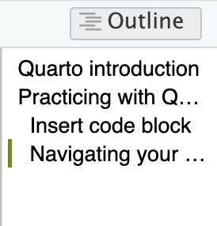

To make your document navigable, it is important to specify headings for each of your document sections via the Style menu.

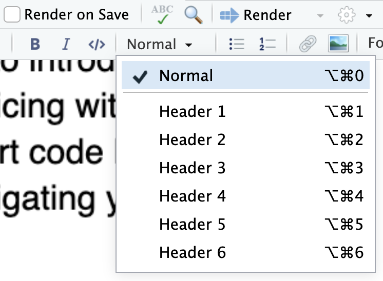

You can also navigate your document by using the menu at the bottom left, which will also let you jump to specific code blocks. This is why it is important to name your code blocks.

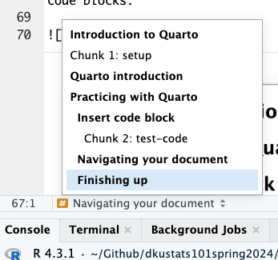

> Add some headers of the appropriate type to your document and double check you can navigate around your document

## Finishing up

Once you’ve done that, please show me your result and then you can proceed to this website [Computations](https://quarto.org/docs/get-started/computations/rstudio.html) tutorial. Please try to modify your document according to the exercises on the tutorial webpage until the end of class.